# Beaks and Flippers

How Beak Shape and Wing Structure Vary Across Penguin Genera

Author

Beaky Blinders: Andrew King, Maria Sans-Fuentes, Stephanie Wu

```r
# Packages used in this report
pkgs <- c("tidyverse", "knitr", "patchwork", "kableExtra", "flextable", "officer")

# Install any package that is not installed yet
missing_pkgs <- pkgs[!pkgs %in% rownames(installed.packages())]
if (length(missing_pkgs) > 0) install.packages(missing_pkgs)

# Load packages
invisible(lapply(pkgs, library, character.only = TRUE))

# Color-blind-friendly palette (adapted from Paul Tol), one color per genus
genus_cols <- c(
  "Aptenodytes" = "#2299CC",  # medium blue
  "Eudyptes"    = "#AA3377",  # purple
  "Eudyptula"   = "#CCBB44",  # yellow
  "Megadyptes"  = "#228833",  # green
  "Pygoscelis"  = "#004488",  # dark navy
  "Spheniscus"  = "#EE6677"   # red/pink
)

# Define symbols by genus, to support Color-blind-friendly choices.
genus_shapes <- c(
  "Aptenodytes" = 16,  # Filled circle
  "Eudyptes" = 17,     # Filled triangle
  "Eudyptula" = 15,    # Filled square
  "Megadyptes"  = 18,  # Filled diamond
  "Pygoscelis" = 3,    # Plus sign (+)
  "Spheniscus" = 8     # Asterisk
)

# Define size for each shape
genus_sizes <- c(Aptenodytes = 2.5, Eudyptes = 2.5, Eudyptula = 2.5,
                 Megadyptes = 3.5, Pygoscelis = 2.5, Spheniscus = 2.5)
```

```r
# Load data
penguins <- read_csv("data/many_penguins.csv")

# rename `hand-wing.index` to hwi
penguins <- penguins %>%
    rename(hwi = 'hand-wing.index')

# make genus, species and sex factors
penguins <- penguins %>%
    mutate(across(c(genus, species, sex), factor))
```

## Introduction

This project uses the “Many Penguins” dataset, featured in TidyTuesday on 2026-07-14 (week 28) and curated by Ben Bolker of McMaster University. It was created as a richer alternative to the Palmer Penguins dataset that includes only 3 species. Many Penguins dataset contains the penguins (Spheniscidae) records from the much larger AVONET database, a global database of morphological, ecological and geographical traits for nearly all bird species (Tobias et al., 2022). The dataset includes 10 distinct morphometric measurements (physical body measurements) for 93 penguins from 18 species within 6 genera. It is cross-sectional and includes measurements of present-day penguin species, which provides a snapshot of penguins today rather than a record of their changes over time. Sample sizes differ widely among genera, and some measurements are missing for several penguins, especially the hand-wing index, which was missing for 20 penguins (Table 1).

We selected this dataset because it lets us explore a question inspired by evolution: do closely related groups that share the same lifestyle end up with similar physical traits? Our goal is to describe and compare how beak shape and wing structure differ between the various penguin genera, and whether different genera remain physically distinct despite sharing an aquatic lifestyle.

```r
# table: number of penguins and species per genus (sample sizes)
# % missing per variable

# Variables used in the analyses
analysis_vars <- c("beak.length_culmen", "beak.length_nares", "beak.width", "beak.depth", "tarsus.length", "hwi")

# Missing values in the beak measurements, by genus
missing_by_genus <- penguins %>%
  group_by(genus) %>%
  summarise(penguins = n(),
            # sum NAs per measurement variable
            across(all_of(analysis_vars), ~ sum(is.na(.x))),
            # sum all the unknown sex values
            sex_unknown = sum(sex == "U"))
```

```r
kable(missing_by_genus,
      col.names = c("Genus", "Penguins", "Culmen length", "Nares length",
                    "Beak width", "Beak depth", "Tarsus length",
                    "Hand-wing index", "Unknown sex")) %>%
    kable_styling() %>%
    column_spec(1, italic = TRUE)
```

Table 1: Number of penguins and of missing values in the variables used in the analyses, by genus. Unknown sex refers to penguins whose sex was recorded as unknown (U).

| Genus | Penguins | Culmen length | Nares length | Beak width | Beak depth | Tarsus length | Hand-wing index | Unknown sex |
| --- | --- | --- | --- | --- | --- | --- | --- | --- |
| Aptenodytes | 10 | 0 | 1 | 0 | 0 | 2 | 2 | 1 |
| Eudyptes | 36 | 0 | 3 | 0 | 1 | 0 | 7 | 15 |
| Eudyptula | 7 | 0 | 3 | 0 | 0 | 1 | 3 | 7 |
| Megadyptes | 4 | 0 | 0 | 0 | 0 | 0 | 0 | 2 |
| Pygoscelis | 17 | 0 | 5 | 0 | 0 | 4 | 5 | 0 |
| Spheniscus | 19 | 0 | 3 | 0 | 0 | 2 | 3 | 17 |

## Question 1: Do penguin genera differ in beak shape?

### Introduction

For this question we explore if penguins from the same genus have similar beak shapes that set them apart from other genera, and which part of the beak contributes most to these differences. The dataset includes four beak measurements: beak length (using two different measures), beak width, and beak depth. Together, they give a good picture of overall beak shape. We also use genus to group the penguins and tarsus length as a proxy for body size, so we can check whether differences in beak shape remain once size is removed. Moreover, since beak shape is closely related to diet and how an animal feeds, looking at these differences across genera may suggest how each group has adapted to find food in the ocean.

### Approach

We used Principal Component Analysis (PCA)[^1] on three beak measurements: culmen length, beak width and beak depth, using only penguins with all three measurements (complete cases; see Table 1 and the Analysis section for how we handled missing values). We log-transformed the measurements, which is standard for allometric data[^2] (Glazier, 2021), and scaled them so that no single measurement had too much weight. To check whether differences between genera were mainly due to size, we also ran the PCA on size-corrected data, using the residuals from regressing each log beak measurement on log tarsus length (a proxy for body size). Because the sign of a principal component (PC) is arbitrary, we reversed PC1 and PC2 in the size-corrected PCA so that both analyses point in the same direction. Because PCA does not quantify how well genera are separated, we also used a linear discriminant analysis (LDA)[^3] with leave-one-out cross-validation[^4] on both the original and the size-corrected measurements.

The bar chart of the loadings (Figure 1) shows how much each beak measurement contributes to each PC: the size of a loading shows how strongly a measurement is linked to the PC, and its sign shows whether the measurement increases or decreases as the PC score increases. Figure 2 shows the biplots of the original and the size-corrected PCA, one above the other with the same axis ranges for direct comparison. Both figures show values as positions along a common scale (the ends of the bars and the points), which is the most accurately judged type of encoding (Cleveland & McGill, 1984), making it easy to see which measurement drives each PC and where each genus falls. In each biplot, the points are the PC scores of each penguin, with genera identified by a color-blind-friendly palette and a different symbol to avoid relying on color alone. Arrows are overlaid to show the loadings: each arrow points in the direction in which that beak measurement increases, so penguins located towards an arrow tend to have larger values of that measurement, and longer arrows indicate measurements that are better represented by the two PCs shown. Combined, the points and arrows show whether penguins of the same genus cluster and which measurements explain these clusters.

### Analysis

```r
# Numbers for inline code in the Approach
r_nares         <- cor(penguins$beak.length_culmen, penguins$beak.length_nares,
                       use = "complete.obs")
n_nares_missing <- sum(is.na(penguins$beak.length_nares))
n_depth_missing <- sum(is.na(penguins$beak.depth))

# Missing nares lengths and sample size for the two most affected genera
eudyptula <- missing_by_genus %>% filter(genus == "Eudyptula")
pygoscelis <- missing_by_genus %>% filter(genus == "Pygoscelis")

# keep penguins with all 3 beak measurements
# Vector with the variable names of the four beak measurements
pca_vars <- c("beak.length_culmen","beak.width", "beak.depth")

# Number of species

# Data frame for analyses: completecases and log transformation
pca_dta <- penguins %>%
    # select variables for PCA analysis
    select(all_of(pca_vars), genus) %>%
    # just keep coplete cases
    filter(complete.cases(.)) %>%
    # log-transform the three beak measurements
    mutate(across(all_of(pca_vars), log, .names = "log_{.col}"))

# Vector with the log transformed variable names
pca_vars_log <- c("log_beak.length_culmen","log_beak.width", "log_beak.depth")
```

Before running the PCA, we explored missing values in the four beak measurements (Table 1). While culmen length and beak width were complete, beak depth was missing for 1 penguin, and nares length was missing for 15 penguins, with the highest proportions in *Eudyptula* (3 of 7) and *Pygoscelis* (5 of 17). Because nares length was strongly correlated with culmen length (r = 0.85), which also measures beak length, we excluded this measure to avoid losing these penguins. We considered imputing their values, but imputation would add little new information and could make genera appear more distinct than they are. Therefore, we ran the PCA on culmen length, beak width and beak depth, using only penguins with all three measurements (complete cases, n = 92).

```r
# original PCA
# PCA o the log transformed 3 measurements variables (not size-corrected)
pca_orig <- prcomp(pca_dta[,pca_vars_log], scale=T)

# Percentage of variance explained by each PC
var_pc <- summary(pca_orig)$importance["Proportion of Variance", ] * 100

# Summary of the explained variance per component
summ_pca_var_nonsize <- summary(pca_orig)$importance

# Loadings of the PCs
summ_pca_load_nonsize <- pca_orig$rotation
```

```r
# size-corrected PCA
# residuals of each log beak measurement on log(tarsus_length)
# Log-transform the beak measurements and tarsus length.
pca_size_dta <- penguins %>%
    select(all_of(pca_vars), tarsus.length, genus) %>%
    filter(complete.cases(.)) %>%
    mutate(across(all_of(c(pca_vars, "tarsus.length")), log, .names = "log_{.col}"))

# Regress each log beak measurement on log tarsus length.
size_lm <- lm(as.matrix(pca_size_dta[, pca_vars_log]) ~ log_tarsus.length,
              data = pca_size_dta)

# Take the residuals: what's left of each beak measurement after removing
# the part explained by body size.
beak_resid <- resid(size_lm)

# Run the PCA on the residuals.
pca_size <- prcomp(beak_resid, scale. = TRUE)

# Flip PC1 and PC2 signs (arbitrary in PCA) so panel B reads like panel A
pca_size$x[, 1:2]        <- -pca_size$x[, 1:2]
pca_size$rotation[, 1:2] <- -pca_size$rotation[, 1:2]

# Percentage of variance explained by each PC
var_pc_size <- summary(pca_size)$importance["Proportion of Variance", ] * 100

# Summary of the explained variance per component
summ_pca_var_size <- summary(pca_size)$importance

# Loadings of the PCs
summ_pca_load_size <- pca_size$rotation
```

For the size-corrected PCA, we used only penguins with all three beak measurements and tarsus length (n = 83), compared with 92 penguins in the original PCA, because tarsus length is also missing for some individuals.

```r
# Table of variance explained by each PC, original and size-corrected PCA
tibble(PC                = colnames(summ_pca_var_nonsize),
       orig_var          = summ_pca_var_nonsize["Proportion of Variance", ]*100,
       orig_cum          = summ_pca_var_nonsize["Cumulative Proportion", ]*100,
       size_var          = summ_pca_var_size["Proportion of Variance", ]*100,
       size_cum          = summ_pca_var_size["Cumulative Proportion", ]*100) %>%
    kable(col.names = c("PC", "Variance (%)", "Cumulative (%)",
                        "Variance (%)", "Cumulative (%)"),
          digits = 1, align = c("l", rep("r", 4))) %>%
    add_header_above(c(" " = 1, "Original" = 2, "Size-corrected" = 2)) %>%
    kable_styling(full_width = FALSE)
```

Table 2: Percentage of variance explained by each principal component in the original and size-corrected PCA of the log-transformed beak measurements.

| PC | Original Variance (%) | Original Cumulative (%) | Size-corrected Variance (%) | Size-corrected Cumulative (%) |
| --- | --- | --- | --- | --- |
| PC1 | 53.9 | 53.9 | 54.1 | 54.1 |
| PC2 | 32.9 | 86.7 | 33.3 | 87.4 |
| PC3 | 13.3 | 100.0 | 12.6 | 100.0 |

In both PCAs (original and size-corrected), PC1 and PC2 together explained most of the variation (86.7% in the original and 87.4% in the size-corrected PCA), while PC3 explained little (Table 2).

```r
# Loadings bar chart function: same design for the original and size-corrected PCA
make_loadings_plot <- function(pca, title) {
    # Percentage of variance explained by each PC
    var <- summary(pca)$importance["Proportion of Variance", ] * 100
    # Loadings of PC1 to PC3 in long format
    loadings_long <- as.data.frame(pca$rotation[, c("PC1", "PC2", "PC3")]) %>%
        rownames_to_column("measurement") %>%
        mutate(measurement = c("Culmen length", "Beak width", "Beak depth")) %>%
        pivot_longer(c(PC1, PC2, PC3), names_to = "PC", values_to = "loading") %>%
        mutate(PC = paste0(PC, " (", round(var[PC], 1), "%)"))
    # Bars of loadings: measurement on the y-axis, loading on the x-axis
    ggplot(loadings_long, aes(x = loading, y = measurement)) +
        # Grey vertical line at zero to separate positive and negative loadings
        geom_vline(xintercept = 0, color = "grey50", linewidth = 0.4) +
        # One bar per measurement, in grey (color is reserved for genus)
        geom_col(fill = "grey45", width = 0.6) +
        # Loading value at the end of each bar
        geom_text(aes(label = sprintf("%.2f", loading),
                      hjust = ifelse(loading < 0, 1.15, -0.15)),
                  size = 3.5, color = "grey25") +
        # Let value labels extend past the panel edge instead of being cut off
        coord_cartesian(clip = "off") +
        # Same range for all panels, with room for the value labels
        scale_x_continuous(limits = c(-1.3, 1.3), breaks = seq(-1, 1, by = 0.5)) +
        labs(title = title, x = "Loading", y = NULL) +
        # Clean white theme with readable text size
        theme_minimal(base_size = 12) +
        # Light vertical gridlines only; bold panel and plot titles
        theme(panel.grid.major.y = element_blank(),
              panel.grid.minor = element_blank(),
              panel.grid.major.x = element_line(color = "grey93", linewidth = 0.3),
              strip.text = element_text(face = "bold"),
              plot.title = element_text(face = "bold", size = 12)) +
        # One panel per PC
        facet_wrap(~ PC)
}
```

Figure 1 shows the loadings of each beak measurement on the three principal components, and Figure 2 shows the position of each penguin on PC1 and PC2, for both the original and the size-corrected PCA.

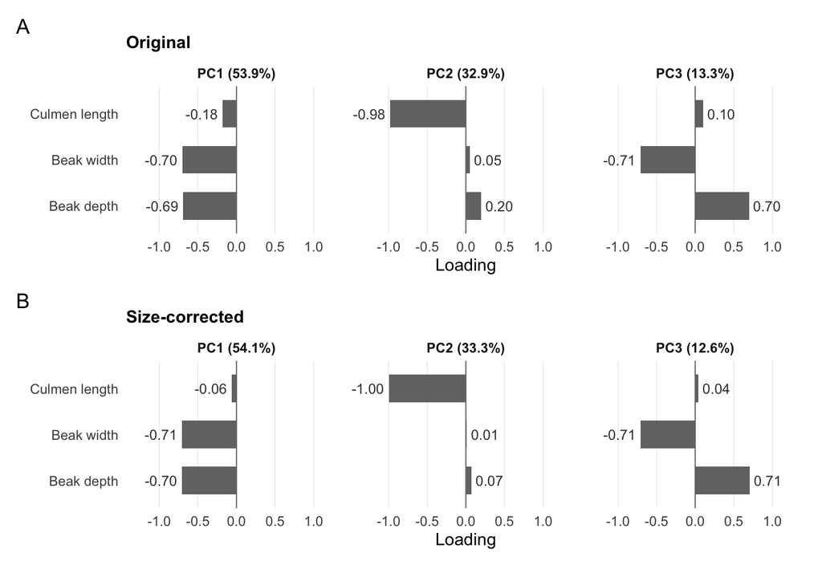

Figure 1: Loadings of the three log-transformed and scaled beak measurements on each principal component: (A) original PCA; (B) size-corrected PCA. Signs of PC1 and PC2 in (B) were reversed to match (A); signs in PCA are arbitrary.

```r
# Figure 1: bar charts of the PCA loadings
p_load_orig <- make_loadings_plot(pca_orig, "Original")
p_load_size <- make_loadings_plot(pca_size, "Size-corrected")

# One above the other, with panel tags A and B
p_load_orig / p_load_size + plot_annotation(tag_levels = "A")
```

We ran the LDA on the same log-transformed beak measurements as the original PCA (Table 3) and on the size-corrected measurements (Table 4), to check whether genera remain separated once body size is removed.

```r
# Linear discriminant analysis: how well can genus be predicted from the beak.
# It uses the same four log beak measurements (predictors) as the PCA, plus genus
# (grouping variable to predict)
# MASS package does lda

# Leave-one-out cross-validation (CV = TRUE): each penguin is classified by a model fitted without that penguin, so the accuracy isn't over-optimistic
lda_cv <- MASS::lda(x = pca_dta[, pca_vars_log],
                    grouping = droplevels(pca_dta$genus),
                    CV = TRUE)

# table of actual vs predicted genus: table(actual, predicted) - no figure?,
# we already will have two figures (PCA + loadings)
# % correct overall and per genus
actual <- droplevels(pca_dta$genus)
predicted <- lda_cv$class

#   Table of actual vs predicted genus (rows = actual, columns = predicted)
cm <- table(actual, predicted)

#   % correct overall
overall_pct <- sum(diag(cm)) / sum(cm) * 100
       #equivalent: mean(predicted == actual) *100

#   % correct per genus (diagonal / row total, because rows = actual)
per_genus_pct <- diag(cm) / rowSums(cm) * 100

# make the table print with footnote of accuracy
cm_tbl <- cbind(as.data.frame.matrix(cm),
                `% correct` = per_genus_pct)
kable(cm_tbl, digits = 2) %>%
    kable_styling() %>%
    column_spec(1, italic = TRUE) %>%
    kableExtra::footnote(general = paste0("Overall accuracy: ", round(overall_pct, 1), "%"),
                         general_title = "")
```

Table 3: Leave-one-out cross-validated LDA classification of genus from log beak measurements (rows = actual, columns = predicted)

|  | Aptenodytes | Eudyptes | Eudyptula | Megadyptes | Pygoscelis | Spheniscus | % correct |
| --- | --- | --- | --- | --- | --- | --- | --- |
| Aptenodytes | 9 | 0 | 0 | 0 | 1 | 0 | 90.00 |
| Eudyptes | 0 | 32 | 0 | 0 | 3 | 0 | 91.43 |
| Eudyptula | 0 | 0 | 7 | 0 | 0 | 0 | 100.00 |
| Megadyptes | 0 | 0 | 0 | 0 | 1 | 3 | 0.00 |
| Pygoscelis | 0 | 2 | 0 | 0 | 15 | 0 | 88.24 |
| Spheniscus | 0 | 0 | 0 | 0 | 0 | 19 | 100.00 |

Overall accuracy: 89.1%

```r
# LDA, using the size-corrected data
# Predictors: residuals of each log beak measurement on log tarsus length
# Leave-one-out cross-validation, as above
lda_cv_size <- MASS::lda(x = beak_resid,
                         grouping = droplevels(pca_size_dta$genus),
                         CV = TRUE)

# Actual vs predicted genus
actual_size    <- droplevels(pca_size_dta$genus)
predicted_size <- lda_cv_size$class

# Table of actual vs predicted genus (rows = actual, columns = predicted)
cm_size <- table(actual_size, predicted_size)

# % correct overall
overall_pct_size <- sum(diag(cm_size)) / sum(cm_size) * 100

# % correct per genus
per_genus_pct_size <- diag(cm_size) / rowSums(cm_size) * 100

# Table with % correct per genus and overall accuracy as a footnote
cm_tbl_size <- cbind(as.data.frame.matrix(cm_size), `% correct` = per_genus_pct_size)
kable(cm_tbl_size, digits = 2) %>%
    kable_styling(full_width = FALSE) %>%
    column_spec(1, italic = TRUE) %>%
    kableExtra::footnote(general = paste0("Overall accuracy: ", round(overall_pct_size, 1), "%"), general_title = "")
```

Table 4: Leave-one-out cross-validated LDA classification of genus from the size-corrected beak measurements (residuals on log tarsus length) (rows = actual genus, columns = predicted genus).

|  | Aptenodytes | Eudyptes | Eudyptula | Megadyptes | Pygoscelis | Spheniscus | % correct |
| --- | --- | --- | --- | --- | --- | --- | --- |
| Aptenodytes | 7 | 0 | 0 | 0 | 1 | 0 | 87.50 |
| Eudyptes | 0 | 32 | 0 | 0 | 3 | 0 | 91.43 |
| Eudyptula | 0 | 0 | 6 | 0 | 0 | 0 | 100.00 |
| Megadyptes | 1 | 0 | 0 | 0 | 0 | 3 | 0.00 |
| Pygoscelis | 0 | 3 | 0 | 0 | 10 | 0 | 76.92 |
| Spheniscus | 0 | 0 | 3 | 0 | 0 | 14 | 82.35 |

Overall accuracy: 83.1%

```r
# Biplot function: same design for the original and size-corrected PCA
make_biplot <- function(pca, genus, labels, title, arrow_scale = 2.5) {
    # Percentage of variance explained by each PC
    var <- summary(pca)$importance["Proportion of Variance", ] * 100
    # PC1 and PC2 scores of each penguin, with its genus
    scores <- as_tibble(pca$x[, 1:2]) |> mutate(genus = genus)
    # Loadings, stretched so the arrows are visible next to the points
    arrows <- as_tibble(pca$rotation[, 1:2] * arrow_scale) |>
        mutate(measurement = c("Length", "Width", "Depth"),
               # Mostly horizontal arrow (TRUE) or mostly vertical (FALSE)
               horiz = abs(PC1) >= abs(PC2),
               # Label just beyond the arrow tip
               lab_x = PC1 * 1.06,
               lab_y = PC2 * 1.06,
               # Horizontal: text starts at the tip and runs outwards;
               # vertical: text centred on the arrow
               hjust = ifelse(horiz, ifelse(PC1 < 0, 1, 0), 0.5),
               # Horizontal: the higher label is nudged up and the lower one down,
               # so labels of arrows pointing the same way do not overlap;
               # vertical: label above or below the tip
               vjust = ifelse(horiz,
                              ifelse(PC2 >= mean(PC2[horiz]), 0.2, 0.8),
                              ifelse(PC2 < 0, 1, 0)))

    ggplot(scores, aes(x = PC1, y = PC2)) +
        # Grey lines at zero (centre of each PC)
        geom_hline(yintercept = 0, color = "grey50", linewidth = 0.4) +
        geom_vline(xintercept = 0, color = "grey50", linewidth = 0.4) +
        # Penguins as points, colored, shaped and sized by genus
        geom_point(aes(color = genus, shape = genus, size = genus)) +
        # Arrows from the centre to each beak measurement's loading
        geom_segment(data = arrows, aes(x = 0, y = 0, xend = PC1, yend = PC2),
                     arrow = arrow(length = unit(2, "mm")),
                     color = "grey25", linewidth = 0.7) +
        # Measurement names next to the arrow tips, with a white halo (no box);
        # force = 0 keeps them exactly where placed
        ggrepel::geom_text_repel(data = arrows,
                                 aes(x = lab_x, y = lab_y, label = measurement,
                                     hjust = hjust, vjust = vjust),
                                 size = 3.5, color = "grey25", fontface = "bold",
                                 bg.color = "white", bg.r = 0.15,
                                 force = 0, force_pull = 0, segment.color = NA,
                                 seed = 1) +
        scale_color_manual(values = genus_cols) +
        scale_shape_manual(values = genus_shapes) +
        scale_size_manual(values = genus_sizes) +
        # Legend in two columns
        guides(color = guide_legend(ncol = 2),
               shape  = guide_legend(ncol = 2),
               size   = guide_legend(ncol = 2)) +
        # Same limits in both panels so they have the same shape and align;
        # equal scale on both axes so distances are not distorted
        coord_equal(xlim = c(-4.2, 4.2), ylim = c(-4.2, 2.5), clip = "off") +
        # Panel title and axis titles with % of variance
        labs(title = title,
             x = paste0("PC1 (", round(var["PC1"], 1), "%)"),
             y = paste0("PC2 (", round(var["PC2"], 1), "%)"),
             color = "Genus", shape = "Genus", size = "Genus") +
        # Clean theme, light grid, no legend
        theme_minimal(base_size = 12) +
        theme(panel.grid.major = element_line(color = "grey93", linewidth = 0.3),
              panel.grid.minor = element_blank(),
              plot.title = element_text(face = "bold", size = 14),
              legend.title = element_blank(),
              legend.position = "inside",
              legend.position.inside = c(1.04, 0.02),
              legend.justification = c(1, 0),
              legend.text = element_text(face = "italic"),
              legend.background = element_rect(fill = "white", color = NA),
              legend.margin = margin(4, 6, 4, 6))
}
```

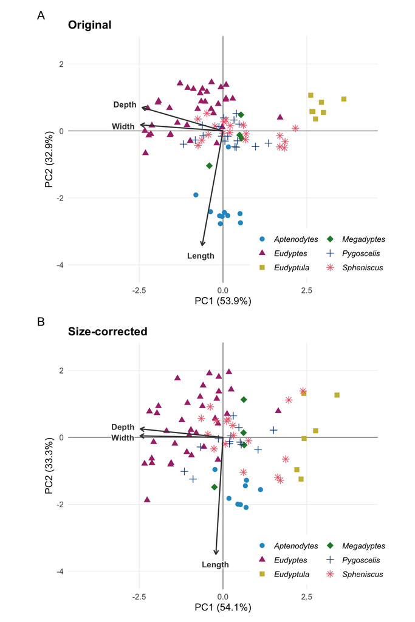

Figure 2: PCA biplots of beak shape across penguin genera: (A) log-transformed beak measurements; (B) after removing the effect of body size (residuals on log tarsus length). Each point is one penguin, colored and shaped by genus; arrows show the loadings of the beak measurements. Percentages show the variance explained by each PC.

```r
# Label positions (right edge of each box), original PCA
genus_labels <- tibble(
    genus   = c("Eudyptes", "Eudyptula", "Aptenodytes",
                "Spheniscus", "Pygoscelis", "Megadyptes"),
    label_x = c(-0.45, 3.85, 2.65, 2.6, 2.05, -0.55),
    label_y = c(1.8, 1.5, -2.6, 0.35, -0.85, -1.05)
)

# Label positions (right edge of each box), size-corrected PCA after flipping
genus_labels_size <- tibble(
    genus   = c("Eudyptes", "Eudyptula", "Aptenodytes",
                "Spheniscus", "Pygoscelis", "Megadyptes"),
    label_x = c(-2.0, 4.5, 3.0, 3.6, -1.2, 2.6),
    label_y = c(1.5, -0.7, -2.6, -1.9, -1.4, 2)
)

# The two biplots
p_orig <- make_biplot(pca_orig, pca_dta$genus, genus_labels, "Original", arrow_scale = 3.5)
p_size <- make_biplot(pca_size, pca_size_dta$genus, genus_labels_size, "Size-corrected", arrow_scale = 3.5)

# Side by side, with panel tags A and B
p_orig / p_size + plot_annotation(tag_levels = "A")
```

### Discussion

**Principal components.** Our PCAs showed that penguin beak variation is organized along two largely distinct dimensions, both before and after size correction (Figure 1; Table 2): beak thickness/robustness (PC1, dominated by beak width and depth) and beak length (PC2, almost entirely determined by culmen length). Because these loadings are negative, lower scores mean thicker and longer beaks, respectively. Although we expected that PC1 would reflect overall beak size, culmen length contributed little to PC1 (-0.18), and even less after size correction (-0.06). Thicker beaks are therefore not necessarily longer, suggesting that beak length and thickness may have evolved somewhat independently, possibly in relation to feeding, which our data cannot test. Because PC1 and PC2 explained most of the variation (about 87% in both PCAs), the biplots (Figure 2) show only these two components.

**Original PCA.** Some genera form distinct groups in the biplot (Figure 2 A). *Aptenodytes* separates along the culmen length arrow, indicating longer beaks, while *Eudyptula* lies opposite the width and depth arrows (narrower, shallower beaks). *Eudyptes* lies in the direction of the width and depth arrows (wider, deeper beaks). *Pygoscelis*, *Spheniscus* and *Megadyptes* overlap in the center. Because this PCA was not corrected for size, the extreme positions of the largest (*Aptenodytes*) and smallest (*Eudyptula*) penguins may partly reflect body size.

**Size-corrected PCA.** After removing the effect of body size, the same overall pattern remains, although the groups are less compact and overlap more (Figure 2 B). *Aptenodytes* still lies along the culmen length arrow, but closer to the center, which suggests that its long beak is partly, but not only, explained by its large size. *Eudyptula* still lies opposite the width and depth arrows, so its beak remains relatively narrow and shallow for its size, and *Eudyptes* still lies towards wider, deeper beaks. The LDA supports this pattern: genus was correctly predicted for 89.1% of penguins with the original measurements and still for 83.1% after size correction (Table 3; Table 4), so penguin genera do differ in beak shape, and these differences are not simply a consequence of body size. The exception is the group of *Pygoscelis*, *Spheniscus* and *Megadyptes*, which continue to overlap in the center; note that no *Megadyptes* penguin was correctly classified, most being assigned to *Spheniscus* (Table 3; Table 4).

## Question 2: Does the hand-wing index still vary among penguin genera?

### Introduction

The variable focused on in this question is the hand-wing index, which measures how elongated a bird’s wing is. It is calculated as Kipp’s distance (the distance from the tip of the first secondary feather to the tip of the longest primary feather) divided by the total wing length, multiplied by 100. Ecologists commonly use it as a single-number proxy for flight efficiency and dispersal ability, with higher values indicating longer, more pointed wings (Sheard et al., 2020).

Penguins are flightless and use their wings primarily as flippers. We are asking whether this trait, normally tied to flight, still differs between genera or has become similar across the group. If differences remain, they may reflect differences in flipper shape related to how each group swims and forages. To answer the question, we compare the hand-wing index among the six penguin genera, and we use tarsus length as a proxy for body size to explore possible reasons for any differences.

### Approach

To address our question we made two plots of different types. Figure 3 is a boxplot of the hand-wing index for each genus, with every penguin overlaid as a jittered point, colored and shaped by genus, and the sample size (n) shown under each genus name. A boxplot is a good fit because it shows the median, spread and outliers of a numeric variable across several groups at once (Heer et al., 2010), and the jittered points keep the raw data visible, so genera with few penguins are not hidden behind a box. Figure 4 is a scatterplot of the hand-wing index against tarsus length (a proxy for body size), with points colored and shaped by genus. A scatterplot is the best choice for showing the relationship between two numeric variables (Saket et al., 2019), and coloring by genus shows whether any trend reflects differences between genera.

To check the visual impression, we tested whether the hand-wing index differs among genera. Because Bartlett’s test indicated unequal variances across genera, we used Welch’s ANOVA, which does not assume equal variances, followed by Games-Howell pairwise comparisons to identify which genera differ. Since some genera have only four penguins, we also ran a Kruskal-Wallis test as a robustness check; if both tests agree, our conclusion does not depend on the choice of test. As the effect size we report omega-squared, which is less biased than eta-squared for small groups and estimates the proportion of variation in hand-wing index explained by genus. Finally, to explore possible reasons for any differences, we compared the mean Kipp’s distance and wing length of each genus (Table 7) and the correlation between the hand-wing index and tarsus length (Spearman’s rank correlation).

### Analysis

```r
# Filter out missing values
q2_data <- penguins |>
    filter(!is.na(hwi), !is.na(genus))

# summary per genus: n, mean, sd, median, 95% CI of the mean
q2_summary <- q2_data |>
    group_by(genus) |>
    summarise(
        n       = n(),
        mean    = mean(hwi),
        sd      = sd(hwi),
        median  = median(hwi),
        se      = sd / sqrt(n),
        ci_low  = mean - qt(0.975, df = n - 1) * se,
        ci_high = mean + qt(0.975, df = n - 1) * se,
        .groups = "drop"
    ) |>
    arrange(desc(mean))

q2_summary %>%
    mutate(ci = paste0(sprintf("%.2f", ci_low), " – ", sprintf("%.2f", ci_high))) %>%
    select(genus, n, mean, sd, median, ci) %>%
    kable(col.names = c("Genus", "n", "Mean", "SD", "Median", "95% CI"),
          digits = 2, align = c("l", rep("r", 5))) %>%
    column_spec(1, italic = TRUE) %>%
    kable_styling()
```

Table 5: Hand-wing index by penguin genus: number of penguins with a hand-wing index (n), mean, standard deviation (SD), median and 95% confidence interval (CI) of the mean.

| Genus | n | Mean | SD | Median | 95% CI |
| --- | --- | --- | --- | --- | --- |
| Megadyptes | 4 | 7.10 | 1.23 | 7.20 | 5.14 – 9.06 |
| Eudyptes | 29 | 5.84 | 1.15 | 5.70 | 5.40 – 6.28 |
| Pygoscelis | 12 | 5.73 | 1.52 | 5.65 | 4.77 – 6.70 |
| Eudyptula | 4 | 5.62 | 1.67 | 5.70 | 2.97 – 8.28 |
| Spheniscus | 16 | 4.16 | 0.72 | 4.00 | 3.77 – 4.54 |
| Aptenodytes | 8 | 3.70 | 0.57 | 3.65 | 3.22 – 4.18 |

We analyzed the 73 of 93 penguins with both a hand-wing index and a tarsus length (see Table 1). The number of penguins with a hand-wing index ranged from 4 to 29 per genus, and mean values ranged from 3.70 (*Aptenodytes*) to 7.10 (*Megadyptes*) (Table 5).

```r
# Welch's ANOVA (main test), Games-Howell post hoc, omega-squared effect size,
# Kruskal-Wallis as a robustness check

# assumption checks (why Welch rather than standard ANOVA)
q2_shapiro <- q2_data |>
    group_by(genus) |>
    filter(n() >= 3) |>
    summarise(shapiro_p = shapiro.test(hwi)$p.value)

q2_bartlett <- bartlett.test(hwi ~ genus, data = q2_data)

# main test: Welch's ANOVA (does not assume equal variances)
q2_welch <- oneway.test(hwi ~ genus, data = q2_data, var.equal = FALSE)

# post hoc: which genera differ
q2_gh <-rstatix::games_howell_test(q2_data, hwi ~ genus)

# effect size: omega-squared
fit <- aov(hwi ~ genus, data = q2_data)
ss  <- summary(fit)[[1]]
omega_sq <- (ss[1, "Sum Sq"] - ss[1, "Df"] * ss[2, "Mean Sq"]) /
    (sum(ss[, "Sum Sq"]) + ss[2, "Mean Sq"])

# robustness check: Kruskal-Wallis (no normality assumption)
q2_kw <- kruskal.test(hwi ~ genus, data = q2_data)
```

Because variances differed among genera (Bartlett’s test, p = 0.038), we used Welch’s ANOVA, which does not assume equal variances. The hand-wing index differed among genera (F = 14.1, p <0.001), with a large effect size ($\omega^2$ = 0.39). Although Shapiro-Wilk tests did not detect departures from normality in any genus, these tests have little power with so few penguins per genus, so we also ran a Kruskal-Wallis test, which does not assume normality; it gave the same result (H = 33.9, p <0.001). Pairwise comparisons (Games-Howell) identified 5 pairs of genera that differed significantly (Table 6).

```r
# Significant pairwise comparisons, with the higher-index genus listed first
q2_gh_sig <- q2_gh |>
      filter(p.adj < 0.05) |>
      # Swap genera when the difference is negative, so all differences are positive
      mutate(higher  = if_else(estimate > 0, group2, group1),
           lower   = if_else(estimate > 0, group1, group2),
           diff    = abs(estimate),
           ci_low  = if_else(estimate > 0, conf.low, -conf.high),
           ci_high = if_else(estimate > 0, conf.high, -conf.low),
           ci      = paste0(sprintf("%.2f", ci_low), " – ", sprintf("%.2f", ci_high)),
           p_adj   = format.pval(p.adj, digits = 2, eps = 0.001)) |>
      arrange(desc(diff))

q2_gh_sig  |>
    select(higher, lower, diff, ci, p_adj) |>
    kable(col.names = c("Higher index", "Lower index", "Difference", "95% CI", "Adjusted p"),
          digits = 2, align = c("l", "l", "r", "r", "r")) |>
    kable_styling(full_width = FALSE) |>
    column_spec(1:2, italic = TRUE)
```

Table 6: Pairs of penguin genera whose mean hand-wing index differed significantly (Games-Howell test, p < 0.05 after Tukey adjustment for multiple comparisons). Difference = mean of the genus with the higher index minus the mean of the genus with the lower index, with its 95% confidence interval. All other pairs did not differ significantly.

| Higher index | Lower index | Difference | 95% CI | Adjusted p |
| --- | --- | --- | --- | --- |
| Megadyptes | Aptenodytes | 3.40 | 0.17 – 6.63 | 0.042 |
| Eudyptes | Aptenodytes | 2.14 | 1.24 – 3.05 | <0.001 |
| Pygoscelis | Aptenodytes | 2.03 | 0.47 – 3.60 | 0.008 |
| Eudyptes | Spheniscus | 1.69 | 0.85 – 2.52 | <0.001 |
| Pygoscelis | Spheniscus | 1.58 | 0.03 – 3.12 | 0.044 |

Figure 3 shows the distribution of the hand-wing index in each genus.

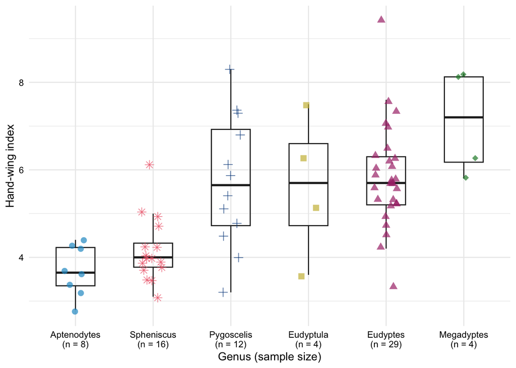

Figure 3: Hand-wing index by penguin genus. Boxplots show the median and interquartile range; points are individual penguins, colored and shaped by genus. Genera are ordered by median hand-wing index, and n is the number of penguins with a hand-wing index.

```r
# geom_boxplot + geom_jitter, color and shape = genus, n per genus
q2_labelled <- q2_data |>
    add_count(genus, name = "n") |>
    mutate(genus_n = fct_reorder(paste0(genus, "\n(n = ", n, ")"),
                                 hwi, .fun = median))

ggplot(q2_labelled, aes(x = genus_n, y = hwi)) +
    geom_boxplot(outlier.shape = NA, fill = NA, color = "grey14", width = 0.5) +
    geom_jitter(aes(color = genus, shape = genus),
                width = 0.15, alpha = 0.7, size = 2.5) +
    scale_y_continuous(name = "Hand-wing index") +
    scale_x_discrete(name = "Genus (sample size)") +
    # Apply pre-defined color, shape nd size for symbols
    scale_color_manual(values = genus_cols, guide = "none") +
    scale_shape_manual(values = genus_shapes, guide = "none") +
    scale_size_manual(values = genus_sizes, guide = "none") +
    theme_minimal() +
    # Color axis text changed to black
    theme(axis.text = element_text(color = "black"))
```

Figure 4 shows the hand-wing index of each penguin against its tarsus length.

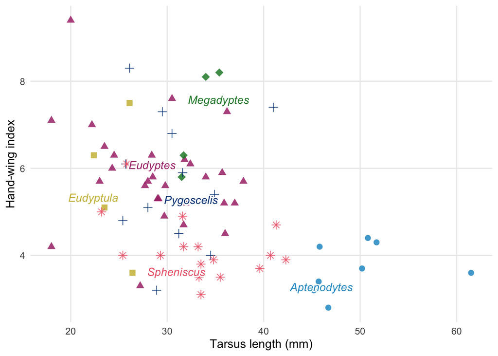

Figure 4: Hand-wing index against tarsus length (a proxy for body size). Each point is one penguin with both measurements, colored and shaped by genus; genus names are placed near the center of each genus.

```r
# geom_pointrange (mean and 95% CI per genus)
# Penguins with both a hand-wing index and a tarsus length
q2_size <- q2_data |>
    filter(!is.na(hwi), !is.na(tarsus.length))

# Centre (median) of each genus and its sample size, for the genus names
# Penguins with both a hand-wing index and a tarsus length
q2_size <- q2_data |>
    filter(!is.na(hwi), !is.na(tarsus.length))

q2_size_labels <- q2_size |>
    group_by(genus) |>
    summarise(n = n(),
              tarsus.length = median(tarsus.length),
              hwi = median(hwi))

ggplot(q2_size, aes(x = tarsus.length, y = hwi)) +
    # Individual penguins, colored, shaped and sized by genus
    geom_point(aes(color = genus, shape = genus, size = genus), alpha = 0.85) +
    # Genus names near the centre of each genus, moved apart if they overlap
    ggrepel::geom_text_repel(data = q2_size_labels,
                             aes(label = genus, color = genus),
                             fontface = 'italic', size = 4,
                             bg.color = 'white', bg.r = 0.15,
                             box.padding = 0.8, min.segment.length = Inf,
                             seed = 1) +
    # Axis titles
    scale_x_continuous(name = "Tarsus length (mm)") +
    scale_y_continuous(name = "Hand-wing index") +
    # Genus colors, shapes and sizes (same in every figure); no legend
    scale_color_manual(values = genus_cols, guide = "none") +
    scale_shape_manual(values = genus_shapes, guide = "none") +
    scale_size_manual(values = genus_sizes, guide = "none") +
    # Clean theme with light gridlines
    theme_minimal(base_size = 12) +
    theme(panel.grid.minor = element_blank())
```

```r
# Exploratory checks for possible reasons why the hand-wing index varies
# Body size: Spearman correlation between hwi and tarsus_length
# exact = FALSE because tied values prevent an exact p-value
size_cor <- cor.test(q2_data$hwi, q2_data$tarsus.length,
                     method = "spearman", exact = FALSE)

# Components of the index: mean kipps_distance and wing_length per genus
q2_components <- q2_data |>
  group_by(genus) |>
  summarise(
    n           = n(),
    mean_kipps  = mean(kipps.distance, na.rm = TRUE),
    mean_wing   = mean(wing.length, na.rm = TRUE),
    mean_hwi    = mean(hwi),
    .groups = "drop"
  ) |>
  # ratio of the two means: a quick check that it tracks mean hwi
  mutate(kipps_wing_ratio = 100 * mean_kipps / mean_wing) |>
  arrange(desc(mean_hwi))

# Sex: number of female, male and unknown-sex penguins per genus
q2_sex <- q2_data |>
  group_by(genus) |>
  summarise(
    F_n = sum(sex == "F", na.rm = TRUE),
    M_n = sum(sex == "M", na.rm = TRUE),
    U_n = sum(sex == "U", na.rm = TRUE),
    .groups = "drop"
  ) |>
  mutate(
    # % male among penguins of known sex
    pct_male = 100 * M_n / (F_n + M_n),
    dominated = case_when(pct_male >= 70 ~ "mostly male",
                          pct_male <= 30 ~ "mostly female",
                          TRUE ~ "balanced")
  )

# This table shows comparing mean Kipp’s distance and wing length across genera
kable(
    q2_components,
    col.names = c("Genus", "Penguins", "Mean Kipp's distance",
                  "Mean wing length", "Mean hand-wing index",
                  "100 × Kipp's / wing"),
    digits = 2,
    align = c("l", rep("r", 5))
) |>
    kable_styling(full_width = FALSE) |>
    column_spec(1, italic = TRUE)
```

Table 7: Mean Kipp’s distance, wing length and hand-wing index by genus. Genera are ordered by mean hand-wing index.

| Genus | Penguins | Mean Kipp's distance | Mean wing length | Mean hand-wing index | 100 × Kipp's / wing |
| --- | --- | --- | --- | --- | --- |
| Megadyptes | 4 | 9.00 | 128.25 | 7.10 | 7.02 |
| Eudyptes | 29 | 6.14 | 105.85 | 5.84 | 5.80 |
| Pygoscelis | 12 | 6.09 | 107.75 | 5.73 | 5.65 |
| Eudyptula | 4 | 3.80 | 67.25 | 5.62 | 5.65 |
| Spheniscus | 16 | 4.06 | 98.94 | 4.16 | 4.11 |
| Aptenodytes | 8 | 6.45 | 174.50 | 3.70 | 3.70 |

The hand-wing index was significantly and negatively correlated with tarsus length (Spearman’s $\rho$ = -0.4, p <0.001; Figure 4). Table 7 shows the mean Kipp’s distance and wing length of each genus, the two components of the hand-wing index.

### Discussion

**Does the hand-wing index vary among genera?** The hand-wing index still differs among penguin genera, but the differences are partial: both Welch’s ANOVA and Kruskal-Wallis test detected differences and genus explained a large share of the variation ($\omega^2$ = 0.39, about 39%). The boxplot (Figure 3) shows two loose groups: *Aptenodytes* and *Spheniscus* have the lowest values (means 3.70 and 4.16), while the other four genera sit higher (means 5.62 to 7.10). Only 5 genus pairs differed significantly (Table 6), all with *Aptenodytes* or *Spheniscus* as the lower-index genus. The largest difference, *Megadyptes* versus *Aptenodytes* (3.40, 95% CI 0.17 to 6.63), has a very wide interval that almost touches zero. The four higher-index genera did not differ significantly, but this is a weak evidence that they are similar, because *Megadyptes* and *Eudyptula* each have only four penguins each and very wide confidence intervals (Table 5). Overall, the hand-wing index has not become uniform across penguins, but the clearest contrasts are between the two lowest-index genera (*Aptenodytes* and *Spheniscus*) and the higher-index genera *Eudyptes* and *Pygoscelis*.

**Why might it differ?** One possible reason is body size. The hand-wing index was negatively correlated with tarsus length (Figure 4), so larger penguins tended to have lower values. The components in Table 7 fit this idea for the largest genus: *Aptenodytes* has the longest wings by far (mean 174.5 mm) but a Kipp’s distance (6.45) similar to *Eudyptes* (6.14), so its low index comes from a long wing, not a short Kipp’s distance. Size is not the whole story, however: *Spheniscus* has a low index (4.16) despite medium-sized wings (98.9 mm), while the smallest genus, *Eudyptula* (wing 67.2 mm), sits among the higher-index genera. Figure 4 also shows that the negative trend is driven mainly by the large *Aptenodytes*, while the other genera overlap in tarsus length with no clear pattern. Because this correlation mixes differences between and within genera, it cannot show whether size itself causes the differences. A second interpretation is the adaptation of wings into flippers: because penguins no longer fly, the hand-wing index may no longer be shaped by flight efficiency. Its variation could reflect differences in flipper shape linked to how each genus swims and forages, although our data contain no diving or foraging variables to test this.

**Limitations.** Four genera have few penguins (4 to 12), which makes their means imprecise and gives the tests little power, so non-significant pairs should not be read as evidence of no difference. Penguins of the same species are not independent observations, and *Eudyptula* and *Megadyptes* are each represented by a single species, so the genus effect partly reflects a handful of species and the p-values are probably too optimistic. Genera are also related by ancestry, so similar values within a genus may reflect shared history rather than a shared lifestyle. Sex was unknown for 37 of 73 penguins, including all *Spheniscus* and *Eudyptula*, so we could not test whether sex affects the hand-wing index. Finally, the hand-wing index was designed for flying birds, so its meaning for penguin flippers is uncertain, and the data are a snapshot of living species with no environmental variables (diet, diving depth, habitat or water temperature), so we can describe how genera differ but cannot test why.

## References

Cleveland, W. S., & McGill, R. (1984). Graphical perception: Theory, experimentation, and application to the development of graphical methods. *Journal of the American Statistical Association*, 79(387), 531–554. https://doi.org/10.1080/01621459.1984.10478080

Glazier, D. S. (2021). Biological scaling analyses are more than statistical line fitting. Journal of Experimental Biology, 224(11) .https://doi.org/10.1242/jeb.241059

Heer, J., Bostock, M., & Ogievetsky, V. (2010). A tour through the visualization zoo. *Communications of the ACM*, 53(6), 59–67. https://doi.org/10.1145/1743546.1743567

Saket, B., Endert, A., & Demiralp, Ç. (2019). Task-based effectiveness of basic visualizations. *IEEE Transactions on Visualization and Computer Graphics*, 25(7), 2505–2512. https://doi.org/10.1109/TVCG.2018.2829750

Sheard, C., Neate-Clegg, M. H. C., Alioravainen, N., Jones, S. E. I., Vincent, C., MacGregor, H. E. A., Bregman, T. P., Claramunt, S., & Tobias, J. A. (2020). Ecological drivers of global gradients in avian dispersal inferred from wing morphology. Nature Communications, 11(1),https://doi.org/10.1038/s41467-020-16313-6

Tobias, J. A., Sheard, C., Pigot, A. L., Devenish, A. J. M., Yang, J., Sayol, F., Neate-Clegg, M. H. C., Alioravainen, N., Weeks, T. L., Barber, R. A., Walkden, P. A., MacGregor, H. E. A., Jones, S. E. I., Vincent, C., Phillips, A. G., Marples, N. M., Montaño-Centellas, F. A., Leandro-Silva, V., Claramunt, S., … Biggs, R. (2022). AVONET: morphological, ecological and geographical data for all birds. Ecology Letters, 25(3), 581–597. https://doi.org/10.1111/ele.13898

## AI Disclosure

**Maria Sans-Fuentes:** Claude (Anthropic) was used to:

- choose a color-blind-friendly palette for our figures (it suggested a palette adapted from Paul Tol’s color schemes, with darkened blues so all colors are clearly visible, one color per genus, and a different point shape per genus as a second cue);
- debug R code, for example how to print the variance explained from a PCA summary with `kable()` (using `summary(pca)$importance`) and why missing color values removed all points from a ggplot;
- place the labels in the PCA biplots (it helped me write the code that positions the measurement names just beyond the end of each loading arrow, keeping the names of arrows that point in the same direction from overlapping, and suggested starting positions for the genus labels, which I then adjusted by hand after checking the rendered figure).
- help configure the document to render in HTML, PDF and Word. This included choosing a package (flextable) that builds the tables in all three formats and adding table of contents for each format.
- how to display very small p-values as “< 0.001” instead of scientific notation using teh base fucntion `format.pval, which was not rendering correctly in the report).
- Review of grammar and typos.

**Andrew King:** Claude (Anthropic) was used to:

- I am unfamiliar with implementing Kruskall Wallace and Welch’s ANOVA so I used Claude to aid in Q2 test for code implementation and interpretation.

**Stephanie Wu:** U of A GenAI was used to:

- I have limited experience with PCA analysis, so I used the University of Arizona’s GenAI tool to assist with Question 1 (size-corrected PCA), including step-by-step explanations to support my interpretation. I also used it to troubleshoot errors in the linear discriminant analysis section and to provide guidance on coding and interpretation issues in the exploratory portion of Question 2.

## Footnotes

[^1]: PCA combines several related measurements into a few new axes, called principal components (PCs), which capture most of the variation in the data. This allows us to summarize the beak measurements in two-dimensional plots.
[^2]: Allometry refers to the way body parts change in proportion to overall body size; for example, larger penguins tend to have larger beaks. These relationships are usually curved on the original scale but become linear after a log transformation. Logging also makes differences between small and large penguins proportional.
[^3]: LDA finds the combinations of measurements that best separate predefined groups (here, genera), and then uses them to assign each penguin to the genus it most resembles.
[^4]: Each penguin is classified by a model fitted without that penguin, so the accuracy is not over-optimistic.